# Analysing and Visualising the Dataset of UFA Film

In this notebook I would like to analyse a dataset that comes from the Super8database.org (an amateur platform collecting Super8 reductions prints from international sources). This dataset contains a list of films that were distributed by UFA-Buscher Film in Germany in the seventies and early eighties. This company specialised in the distribution of "reduction prints" (reduced versions of films to be watched at home) on Super8-mm film material and had a specific library of film genres. In my analysis I want to give a glimpse in form of a "distant reading" of the film library, the most represented genres, directors, country of origins and original language of the distributions, in order to understand what was popular among reduction prints buyers.

The Dataset has been enriched with additional data through the software Open Refine. To the original Ufa Title of the films, the number of reels, color or b/w type I added and reconciled the original title (the Ufa title was usually different than the original copy because reduction prints were often edited and shortened versions). From the original title I could add other fields as columns: director, original language, genre (limited to only 1 item), IMDb ID, year of production and country of origin.

To proceed to further analyse and later visualize my dataset I download the packages for python:

```python
#download the packages for doing analysis and visualizations

import numpy as np
import pandas as pd
import matplotlib.pyplot as plt
```

```python
#reading dataset with pandas, overview of the table content
ufa_df = pd.read_csv('ufa_dataset_reconciled_py.csv',na_values=[0] )
```

### First let just take a look at the fields on the head of my dataset

Which columns are there? how many rows does the dataset have?

```python
ufa_df.head() #first look at the dataset
```

|  | id | distributor | Ufa Title | Original title | Reconciled Title | country of origin | genre | IMDb ID | director | original language of film or TV show | reels | color | sound | year | tags |
| --- | --- | --- | --- | --- | --- | --- | --- | --- | --- | --- | --- | --- | --- | --- | --- |
| 0 | 5769 | Ufa | Agenten sterben einsam | Where Eagles Dare | Where Eagles Dare | United Kingdom | adventure film | tt0065207 | Brian G. Hutton | English | 3x400 | color | sound | 1968.0 | Adventure, Action, War, Digest |
| 1 | 5771 | Ufa | Alien | Alien | Alien | United States of America | horror film | tt0078748 | Ridley Scott | English | 400 | color | sound | 1979.0 | Sci-Fi, Horror, Digest |
| 2 | 7778 | Ufa | Alpenglühn im Dirndlrock | Alpenglühn im Dirndlrock | Alpine Glow in Dirndlrock | Germany | comedy film | tt0071126 | Sigi Rothemund | German | 3x400 | color | sound | 1974.0 | Comedy |
| 3 | 5873 | Ufa | A Star Is Born | A Star Is Born | A Star Is Born | United States of America | musical film | tt0075265 | Frank Pierson | English | 400 | color | sound | 1976.0 | Musical, Drama, Digest |
| 4 | 6249 | Ufa | Auch die Engel essen Bohnen | Anche gli angeli mangiano fagioli | Even Angels Eat Beans | Italy | buddy film | tt0069713 | Enzo Barboni | Italian | 4x400 | color | sound | 1973.0 | Action, Crime, Comedy |

```python
#counting rows

rows_number = len(ufa_df.index)
print("The dataset has " + str(rows_number) + " rows")
```

```
The dataset has 148 rows
```

Now I want to know which datatypes are in my dataset, you may see that the date is a float.

```python
#which data types I have
display(ufa_df.dtypes)
```

```
id                                        int64
distributor                              object
Ufa Title                                object
Original title                           object
Reconciled Title                         object
country of origin                        object
genre                                    object
IMDb ID                                  object
director                                 object
original language of film or TV show     object
reels                                    object
color                                    object
sound                                    object
year                                    float64
tags                                     object
dtype: object
```

Now I have to change the datatype from float to integer

```python
#check if I can convert year to int > look online for solutions on Stackoverflow:

#df = df.dropna(subset=['x'])
print(ufa_df[ufa_df['year'].isnull()])
ufa_df['year'] = pd.to_numeric(ufa_df['year'], errors='coerce')
ufa_df = ufa_df.dropna(subset=['year'])


ufa_df['year'] = ufa_df['year'].astype(int)
ufa_df.head()
```

```
       id distributor     Ufa Title Original title Reconciled Title  \
127  5702         Ufa  Trailerrolle   Trailerrolle     Trailerrolle

    country of origin    genre IMDb ID director  \
127           Germany  Trailer     NaN   VV.AA.

    original language of film or TV show reels  color  sound  year     tags
127                              Various   200  color  sound   NaN  Trailer
```

|  | id | distributor | Ufa Title | Original title | Reconciled Title | country of origin | genre | IMDb ID | director | original language of film or TV show | reels | color | sound | year | tags |
| --- | --- | --- | --- | --- | --- | --- | --- | --- | --- | --- | --- | --- | --- | --- | --- |
| 0 | 5769 | Ufa | Agenten sterben einsam | Where Eagles Dare | Where Eagles Dare | United Kingdom | adventure film | tt0065207 | Brian G. Hutton | English | 3x400 | color | sound | 1968 | Adventure, Action, War, Digest |
| 1 | 5771 | Ufa | Alien | Alien | Alien | United States of America | horror film | tt0078748 | Ridley Scott | English | 400 | color | sound | 1979 | Sci-Fi, Horror, Digest |
| 2 | 7778 | Ufa | Alpenglühn im Dirndlrock | Alpenglühn im Dirndlrock | Alpine Glow in Dirndlrock | Germany | comedy film | tt0071126 | Sigi Rothemund | German | 3x400 | color | sound | 1974 | Comedy |
| 3 | 5873 | Ufa | A Star Is Born | A Star Is Born | A Star Is Born | United States of America | musical film | tt0075265 | Frank Pierson | English | 400 | color | sound | 1976 | Musical, Drama, Digest |
| 4 | 6249 | Ufa | Auch die Engel essen Bohnen | Anche gli angeli mangiano fagioli | Even Angels Eat Beans | Italy | buddy film | tt0069713 | Enzo Barboni | Italian | 4x400 | color | sound | 1973 | Action, Crime, Comedy |

Let's see also what is in my dataset. As you may see many statistical values cannot be counted since most of data entries in my datasets are strings.

```python
ufa_df.describe(include='all')
```

|  | id | distributor | Ufa Title | Original title | Reconciled Title | country of origin | genre | IMDb ID | director | original language of film or TV show | reels | color | sound | year | tags |
| --- | --- | --- | --- | --- | --- | --- | --- | --- | --- | --- | --- | --- | --- | --- | --- |
| count | 147.000000 | 147 | 147 | 147 | 147 | 147 | 147 | 147 | 147 | 147 | 147 | 147 | 147 | 147.000000 | 147 |
| unique | NaN | 1 | 144 | 144 | 143 | 15 | 31 | 143 | 121 | 9 | 10 | 2 | 1 | NaN | 112 |
| top | NaN | Ufa | Der Exorzist | The Exorcist | Enter the Dragon | United States of America | comedy film | tt0070034 | Rudolf Zehetgruber | English | 3x400 | color | sound | NaN | Comedy |
| freq | NaN | 147 | 2 | 2 | 2 | 43 | 25 | 2 | 5 | 65 | 76 | 135 | 147 | NaN | 6 |
| mean | 6479.700680 | NaN | NaN | NaN | NaN | NaN | NaN | NaN | NaN | NaN | NaN | NaN | NaN | 1970.632653 | NaN |
| std | 748.062872 | NaN | NaN | NaN | NaN | NaN | NaN | NaN | NaN | NaN | NaN | NaN | NaN | 9.157736 | NaN |
| min | 2484.000000 | NaN | NaN | NaN | NaN | NaN | NaN | NaN | NaN | NaN | NaN | NaN | NaN | 1936.000000 | NaN |
| 25% | 6066.000000 | NaN | NaN | NaN | NaN | NaN | NaN | NaN | NaN | NaN | NaN | NaN | NaN | 1968.000000 | NaN |
| 50% | 6320.000000 | NaN | NaN | NaN | NaN | NaN | NaN | NaN | NaN | NaN | NaN | NaN | NaN | 1973.000000 | NaN |
| 75% | 6634.500000 | NaN | NaN | NaN | NaN | NaN | NaN | NaN | NaN | NaN | NaN | NaN | NaN | 1977.000000 | NaN |
| max | 8726.000000 | NaN | NaN | NaN | NaN | NaN | NaN | NaN | NaN | NaN | NaN | NaN | NaN | 1981.000000 | NaN |

### How many films are in my dataset that have been produced in a certain year?

To reply to this question I will first I import Seaborn for displaying the charts, second I have to count some of the values frequency since my data entries are often just strings.

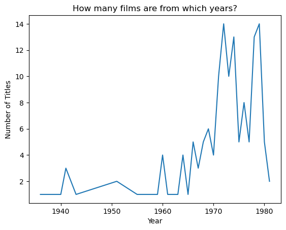

```python
#Line chart of films per year of production
#import Seaborn

#dataframe['Column'].value_counts()

import matplotlib.pyplot as plt

import seaborn as sns

# Lineplot: wrong kind of plot, data not continuous but categorical
#count of Titles

counts=ufa_df['year'].value_counts() #counting values for year

#print(counts)
sns.lineplot(x=counts.index,y=counts.values) #using lineplot

#color palette
sns.color_palette("mako", as_cmap=True)

# Titel und Labels
plt.title('How many films are from which years?')
plt.xlabel('Year')
plt.ylabel('Number of Titles')

plt.show()
```

In this case the lineplot is not the best visualization because my data are not continuous for the years. So the best way would be to produce a historgram.

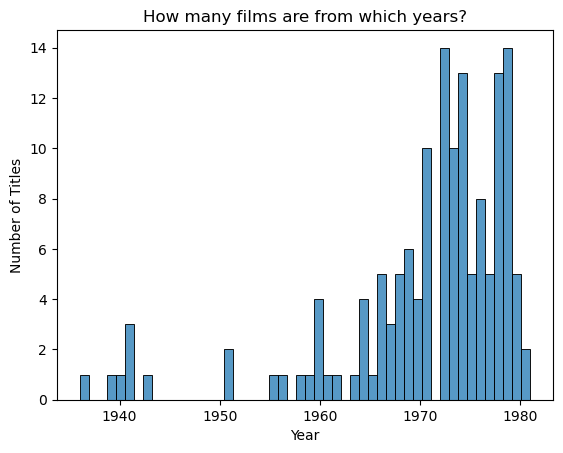

```python
#histogram of titles per year

sns.histplot(ufa_df["year"], bins=50)

# Titel und Labels
plt.title('How many films are from which years?')
plt.xlabel('Year')
plt.ylabel('Number of Titles')

plt.show()
```

## Now I want to visualize the frequency of certain genres within my film dataset

First I need to count how many times certain genres (as strings) are showing in my dataset

```python
#Titles per year genres


# Get count duplicates single column using dataframe.pivot_table()
genres_df = ufa_df.pivot_table(index = ['genre'], aggfunc ='size')
print(genres_df)
```

```
genre
Spaghetti Western                      7
Western film                           1
action film                           19
adventure film                         5
anthology film                         1
biographical film                      2
buddy film                             3
comedy drama                           1
comedy film                           25
crime film                             5
crime television series                2
documentary film                       1
drama film                             9
erotic film                            2
fantasy film                           2
fiction film                           1
heist film                             3
horror film                           18
musical film                           6
mystery film                           1
propaganda film                        2
romantic comedy                        3
science fiction film                  12
science fiction television program     1
space opera                            1
speculative/fantastic fiction film     1
splatter film                          2
spy film                               2
sword-and-sandal film                  1
teen film                              2
war film                               6
dtype: int64
```

Looking at other people work on film lists I also want to show only the most frequent genres and group those that are coming less often into a single group in order to visualize it better in a chart. I took part of the code from github page of CamPaiva.

```python
#counting the frequency of genres per film

genre_list = pd.DataFrame(ufa_df.genre.value_counts())
genre_list["Frequency"] = ufa_df.genre.value_counts(normalize=True)
genre_list = genre_list.reset_index()
genre_list = genre_list.rename(columns = {"index": "genre", "count": "Number of Films"})
genre_list.loc[genre_list.Frequency < 0.03, 'genre'] = 'Others'
genre_list = (genre_list
                .groupby('genre').sum()
                .sort_values('Number of Films', ascending=False)
                .reset_index())
print(genre_list)
```

[output not shown]

Now with the genre_list I can create another histogram of the most frequent genres.

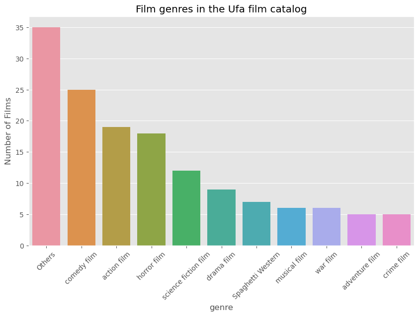

```python
#histogram from genre_list
plt.style.use('ggplot')
plt.figure(figsize=(10, 6))
sns.barplot(data=genre_list, x="genre", y="Number of Films")
plt.title("Film genres in the Ufa film catalog")
sns.color_palette("Set3", as_cmap=True)
plt.savefig("Ufa_catalog_genres.jpg", dpi=300)
plt.xticks(rotation = 45)
plt.show()
```

A pie chart might represent the percentages within the whole dataset better. Let's see. I added a legend on the bottom right corner. We might see that the most represented genres are comedy, action and horror film. Even science fiction has a higher percentage than drama. This shows how this dataset of films might differ from the most popular films in theaters. These films were only distributed for the home entertainment.

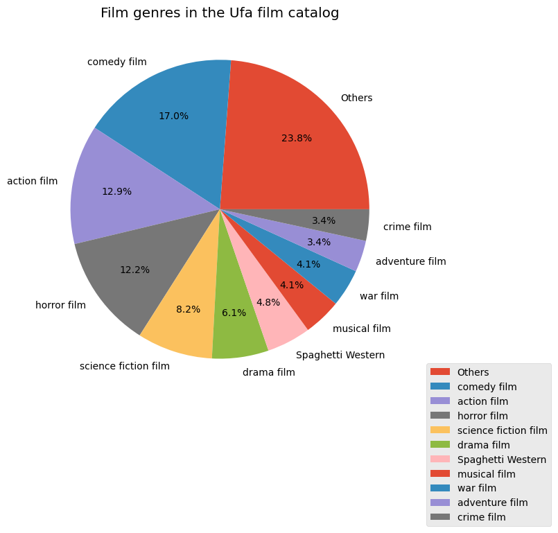

```python
#pie chart
plt.figure(figsize=(9, 7))
plt.pie(genre_list["Number of Films"], labels = genre_list["genre"], colors=None, autopct='%1.1f%%', pctdistance=0.7)
plt.title("Film genres in the Ufa film catalog")
plt.legend(loc="upper right",bbox_to_anchor=(1.40,0.10))
plt.savefig("Genres_Pie.jpg", dpi=250, bbox_inches='tight')
```

## Analysing Country of Origin and Original language

We might now do the same operation of analysis to look at the most represented countries of origin and original language in the dataset, and later also count the most represented directors.

```python
#counting the frequency of Country of origin
#counting the frequency of genres per film

country_list = pd.DataFrame(ufa_df.country of origin.value_counts())
country_list["Frequency"] = ufa_df.country of origin.value_counts(normalize=True)
country_list = country_list.reset_index()
country_list = country_list.rename(columns = {"index": "country of origin", "count": "Number of Films"})
country_list.loc[country_list.Frequency < 0.03, 'country of origin'] = 'Others'
country_list = (country_list
                .groupby('country').sum()
                .sort_values('Number of Films', ascending=False)
                .reset_index())
print(country_list)
```

```
  Cell In[15], line 4
    country_list = pd.DataFrame(ufa_df.country of origin.value_counts())
                                ^
SyntaxError: invalid syntax. Perhaps you forgot a comma?
```

Because the column "country of origin" has white space in the title I cannot implement in the code above the method. So I need to change the name of the columns to make the operation easier.

```python
#syntax of changing : rankings_pd.rename(columns = {'test':'TEST'}, inplace = True)

ufa_df.rename(columns = {'Ufa Title':'ufa_title', 'Original title':'original_title','Reconciled Title':'reconciled_title','country of origin':'country_of_origin', 'IMDb ID':'IMDb_id','original language of film or TV show':'original_language'}, inplace=True)
ufa_df.head()
```

|  | id | distributor | ufa_title | original_title | reconciled_title | country_of_origin | genre | IMDb_id | director | original_language | reels | color | sound | year | tags |
| --- | --- | --- | --- | --- | --- | --- | --- | --- | --- | --- | --- | --- | --- | --- | --- |
| 0 | 5769 | Ufa | Agenten sterben einsam | Where Eagles Dare | Where Eagles Dare | United Kingdom | adventure film | tt0065207 | Brian G. Hutton | English | 3x400 | color | sound | 1968 | Adventure, Action, War, Digest |
| 1 | 5771 | Ufa | Alien | Alien | Alien | United States of America | horror film | tt0078748 | Ridley Scott | English | 400 | color | sound | 1979 | Sci-Fi, Horror, Digest |
| 2 | 7778 | Ufa | Alpenglühn im Dirndlrock | Alpenglühn im Dirndlrock | Alpine Glow in Dirndlrock | Germany | comedy film | tt0071126 | Sigi Rothemund | German | 3x400 | color | sound | 1974 | Comedy |
| 3 | 5873 | Ufa | A Star Is Born | A Star Is Born | A Star Is Born | United States of America | musical film | tt0075265 | Frank Pierson | English | 400 | color | sound | 1976 | Musical, Drama, Digest |
| 4 | 6249 | Ufa | Auch die Engel essen Bohnen | Anche gli angeli mangiano fagioli | Even Angels Eat Beans | Italy | buddy film | tt0069713 | Enzo Barboni | Italian | 4x400 | color | sound | 1973 | Action, Crime, Comedy |

Now I retry the code I used above to visualize the most represented countries

```python
country_list = pd.DataFrame(ufa_df.country_of_origin.value_counts())
country_list["Frequency"] = ufa_df.country_of_origin.value_counts(normalize=True)
country_list = country_list.reset_index()
country_list = country_list.rename(columns = {"index": "country_of_origin", "count": "Number of Films"})
country_list.loc[country_list.Frequency < 0.03, 'country_of_origin'] = 'Others'
country_list = (country_list
                .groupby('country_of_origin').sum()
                .sort_values('Number of Films', ascending=False)
                .reset_index())
print(country_list)
```

```
          country_of_origin  Number of Films  Frequency
0  United States of America               43   0.292517
1                   Germany               30   0.204082
2                     Italy               28   0.190476
3            United Kingdom               17   0.115646
4                    Others               16   0.108844
5                    France                8   0.054422
6                     Japan                5   0.034014
```

Let`s create a Pie Chart showing the most represented countries of origin in my dataset. As you may see Germany, USA, Italy and UK are the most represented.

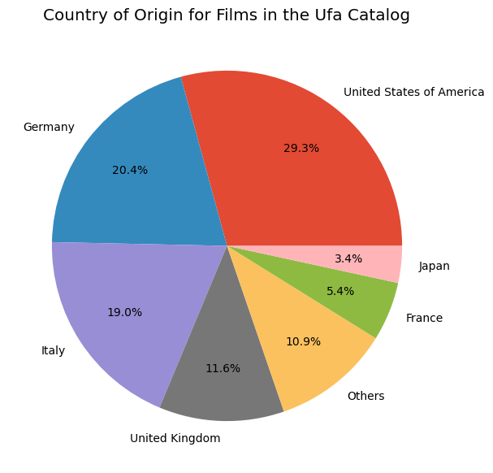

```python
#pie chart
plt.figure(figsize=(9, 7))
plt.pie(country_list["Number of Films"], labels = country_list["country_of_origin"], autopct='%1.1f%%', pctdistance=0.7)
plt.title("Country of Origin for Films in the Ufa Catalog")
plt.savefig("Country_Pie.jpg", dpi=250, bbox_inches='tight')
```

## And who are the most represented directors?

Again I create a list, which chart would fit better? To include all names and make them visible I try to show the dataframe with a heatmap, thus a color code.

```python
director_list = pd.DataFrame(ufa_df.director.value_counts())
director_list["Frequency"] = ufa_df.director.value_counts(normalize=True)
director_list = director_list.reset_index()
director_list = director_list.rename(columns = {"index": "director", "count": "Number of Films"})
director_list.loc[director_list.Frequency < 0.013605, 'director'] = 'Others'

print(director_list)
```

[output not shown]

```python
# displaying dataframe as an heatmap
# with diverging colourmap as virdis
director_list.style.background_gradient(cmap ='viridis')\
        .set_properties(**{'font-size': '10px'})
```

|  | director | Number of Films | Frequency |
| --- | --- | --- | --- |
| 0 | Rudolf Zehetgruber | 5 | 0.034014 |
| 1 | Sergio Corbucci | 4 | 0.027211 |
| 2 | Robert Clouse | 3 | 0.020408 |
| 3 | Gianfranco Parolini | 3 | 0.020408 |
| 4 | Andrew V. McLaglen | 2 | 0.013605 |
| 5 | Antonio Margheriti | 2 | 0.013605 |
| 6 | Harald Reinl | 2 | 0.013605 |
| 7 | Sergio Sollima | 2 | 0.013605 |
| 8 | Gordon Hessler | 2 | 0.013605 |
| 9 | Werner Jacobs | 2 | 0.013605 |
| 10 | William Friedkin | 2 | 0.013605 |
| 11 | Ruggero Deodato | 2 | 0.013605 |
| 12 | George P. Cosmatos | 2 | 0.013605 |
| 13 | Jun Fukuda | 2 | 0.013605 |
| 14 | Ishirō Honda | 2 | 0.013605 |
| 15 | Franz Josef Gottlieb | 2 | 0.013605 |
| 16 | Enzo Barboni | 2 | 0.013605 |
| 17 | Walter Boos | 2 | 0.013605 |
| 18 | Sigi Rothemund | 2 | 0.013605 |
| 19 | Others | 1 | 0.006803 |
| 20 | Others | 1 | 0.006803 |
| 21 | Others | 1 | 0.006803 |
| 22 | Others | 1 | 0.006803 |
| 23 | Others | 1 | 0.006803 |
| 24 | Others | 1 | 0.006803 |
| 25 | Others | 1 | 0.006803 |
| 26 | Others | 1 | 0.006803 |
| 27 | Others | 1 | 0.006803 |
| 28 | Others | 1 | 0.006803 |
| 29 | Others | 1 | 0.006803 |

[output cut: 91 more lines]

## Now I create a list based on the original language:

```python
language_list = pd.DataFrame(ufa_df.original_language.value_counts())
language_list["Frequency"] = ufa_df.original_language.value_counts(normalize=True)
language_list = language_list.reset_index()
language_list = language_list.rename(columns = {"index": "original_language", "count": "Number of Films"})
language_list.loc[language_list.Frequency < 0.013605, 'original_language'] = 'Others'
language_list = (language_list
                .groupby('original_language').sum()
                .sort_values('Number of Films', ascending=False)
                .reset_index())

print(language_list)
```

```
  original_language  Number of Films  Frequency
0           English               65   0.442177
1            German               34   0.231293
2           Italian               30   0.204082
3            French                6   0.040816
4          Japanese                5   0.034014
5           Spanish                4   0.027211
6            Others                3   0.020408
```

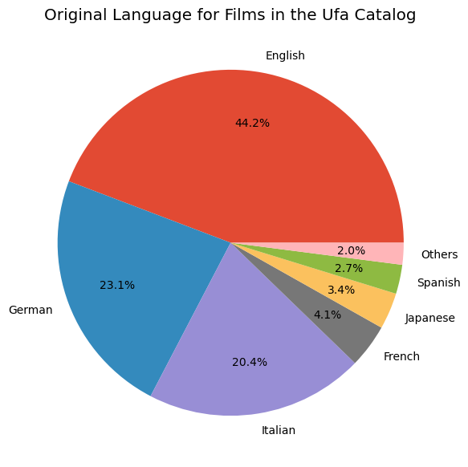

```python
#pie chart
plt.figure(figsize=(9, 7))
plt.pie(language_list["Number of Films"], labels = language_list["original_language"], autopct='%1.1f%%', pctdistance=0.7)
plt.title("Original Language for Films in the Ufa Catalog")
plt.savefig("Language_Pie.jpg", dpi=250, bbox_inches='tight')
```

This Pie Charts shows how it is similar to the one with Country of origins, but of course English films and American films are now part of the same original language slice. We might confront them bringing both Pie charts displayed near each other:

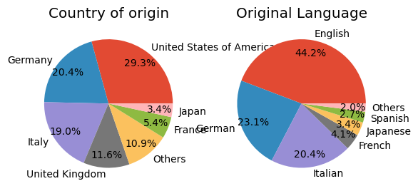

```python
#code for showing two charts side by side

#first pie chart
plt.subplot(1, 2, 1) # row 1, col 2 index 1
plt.pie(country_list["Number of Films"], labels = country_list["country_of_origin"], autopct='%1.1f%%', pctdistance=0.8)
plt.title("Country of origin")

#second pie chart
plt.subplot(1, 2, 2) # index 2
plt.pie(language_list["Number of Films"], labels = language_list["original_language"], autopct='%1.1f%%', pctdistance=0.8)
plt.title("Original Language")

#showing both
plt.show()
```

My analyisis is a way to look into my dataset from "above". This distant glimpse helps me to have an overview of the film material within my dataset and it shows how this might be interesting to be investigate more into detail. For instance which exactly are the italian films present into my dataset? Which kind of genre is more represented within the italian films of the dataset? This might be the material for a further elaboration and analysis.